# PD_1

Konrad Welkier

8 03 2020

## Wstęp

W poniższym sprawozdaniu prezentuję wyniki eksploracji przeprowadzonej na zbiorze dotyczącym chorób serca, do którego dane zebrane zostały wśród pacjentów szpitala w Cleveland.

Na wstępie załadujmy odpowiednie biblioteki oraz analizowany zbiór danych.

```r
library(DataExplorer)
library(ggplot2)
library(dplyr)
data <- read.csv("heart_disease_weka_dataset.csv")
```

## Początkowa obróbka danych

Na tym etapie zamienimy na faktory odpowiednie kolumny, a także podzielimy nasz zbiór danych na dwa pozbiory, z których jeden zawierać będzie pacjentów zdiagnozowanych jako chorych, drugi natomiast osoby, które wg lekarzy nie mają problemów z sercem. Podział ten przyda się do jednego z porównań, które zaprezentowane zostanie w dalszej części sprawozdania.

```r
data$sex <- as.factor(data$sex)
data$cp <- as.factor(data$cp)
data$fbs <- as.factor(data$fbs)
data$restecg <- as.factor(data$restecg)
data$exang <- as.factor(data$exang)
data$slope <- as.factor(data$slope)
data$ca <- as.factor(data$ca)
data$thal <- as.factor(data$thal)
disease <- data %>% filter(data$num == 0)
no_disease <- data %>% filter(data$num == 1)
data$num <- as.factor(data$num)
```

## Ogólne informacje o zbiorze

Właściwą pracę ze zbiorem zacznijmy od zaprezentowania podstawowych faktów:

```r
summary(data)
```

```
##       age        sex     cp         trestbps          chol       fbs
##  Min.   :29.00   0: 97   1: 23   Min.   : 94.0   Min.   :126.0   0:258
##  1st Qu.:48.00   1:206   2: 50   1st Qu.:120.0   1st Qu.:211.0   1: 45
##  Median :56.00           3: 86   Median :130.0   Median :241.0
##  Mean   :54.44           4:144   Mean   :131.7   Mean   :246.7
##  3rd Qu.:61.00                   3rd Qu.:140.0   3rd Qu.:275.0
##  Max.   :77.00                   Max.   :200.0   Max.   :564.0
##  restecg    thalach      exang      oldpeak     slope        ca
##  0:151   Min.   : 71.0   0:204   Min.   :0.00   1:142   -1e+05:  4
##  1:  4   1st Qu.:133.5   1: 99   1st Qu.:0.00   2:140   0     :176
##  2:148   Median :153.0           Median :0.80   3: 21   1     : 65
##          Mean   :149.6           Mean   :1.04           2     : 38
##          3rd Qu.:166.0           3rd Qu.:1.60           3     : 20
##          Max.   :202.0           Max.   :6.20
##      thal     num
##  -1e+05:  2   0:164
##  3     :166   1:139
##  6     : 18
##  7     :117
##
##
```

W oczy rzucają się wartości -1e+05 w kolumnach ca oraz thal, ale występują one jedynie w kilku przypadkach, więc możemy uznać, że są to jedynie niewiele zmieniające zbiór błędy (te wartości zdają się być problemem, ponieważ w opisie zbioru, w tych kolumnach, takie wartości nie są uwzględnione). Ponadto możemy zauważyć, że na faktory zamienione zostały wszystkie kolumny, które takiej zamiany wymagały. Wreszcie możemy zaobserwować, że rozważani pacjenci są w zdecydowanej większości mężczyznami, natomiast w kwestii wieku mają oni od 29 do 77 lat.

## Pierwsze zależności

Teraz skorzystamy z funkcji plot_correlation, która wskaże możliwości dalszej eksploracji zbioru.

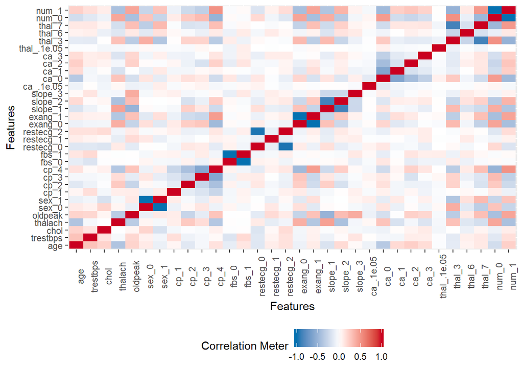

```r
plot_correlation(data)
```

## Interesujące zależności

W najważniejszej części sprawozdania skupimy się na rozwijaniu zależności znalezionych w “pierwszych zależnościach” wykorzystując w tym celu zróżnicowane wykresy.

# Zależność nr 1

Zaczniemy od sprawdzenia zależności pomiędzy spoczynkownym ciśnieniem krwi (mm Hg) [trestbps], a zdiagnozowaną chorobą serca, która chociaż nie została zaobserwowana na wykresie powyżej, intuicyjnie zdaje się występować. Tej zależności przyjrzymy się rozbijając otrzymany wykres na 4 części w zależności od rodzaju bólu, który odczuwają pacjenci.

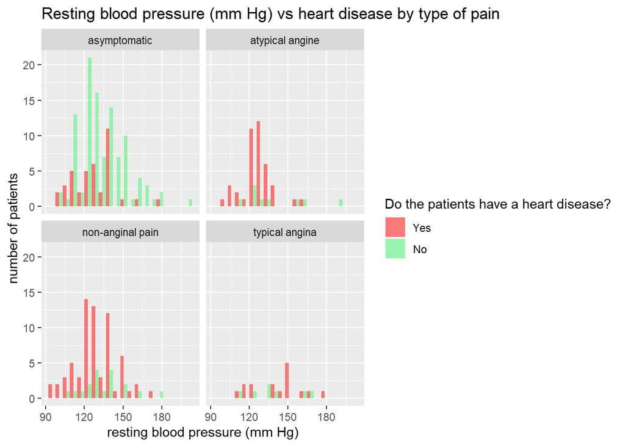

Podsumowując ten etap można zauważyć, że w przypadku bólu bezobjawowego (asymptomatic) zdecydowana większość pacjentów nie została zdiagnozwaną jako posiadający problemy z sercem. Przeciwną tendencję widać natomiast u pacjentów skarżących się na bóle określone jako “atypical angine” oraz “non-anginal pain”. Wreszcie, u pacjentów, których ból opisany został jako “typical angina”, nie można jednoznacznie zdiagnozować wiodącego trendu. Jednkże najciekawszą obesrwacją z powyższego wykresu zdaje się być obalenie mitu, że im wyższe ciśnienie spoczynkowe, tym większa szansa posiadnia problemów z sercem. Generalnie można natomiast stwierdzic, że średnie spoczynkowe ciśnienie krwi u badanych pacjentów to 120-140 mm Hg.

# Zależność nr 2

Zależność z tego pozrodziału została zaobserwowana na wykresie korelacji i odnosi się do współczynnika otrzymywanego podczas badania EKG, który porównuje pracę serca podczas wysiłku oraz podczas odpoczynku (ST depression). Badana relacja zaprezentowana zostanie za pomocą wykresu gęstości.

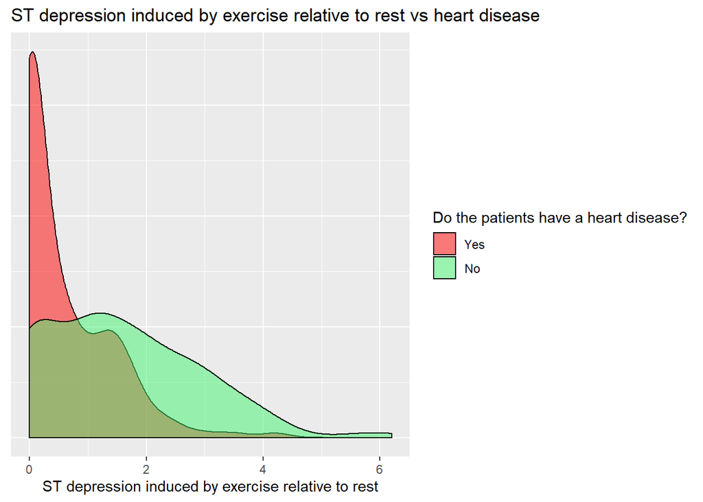

Z powyższego wykresu można jasno wywnioskować, że ST depression jest znacząco inne u pacjentów chorych i u pacjentów zdrowych. Dla zdecydowanej większości pacjentów chorych ST depression ma wartość mniejszą od 2, podczas gdy u pacjentów zdrowych stosunkowo często pojawić się mogą wartości nawet do 4. Na tej podstwie można określić, że posiadanie ST depression powyżej 2 dość silnie sugeruje nieposiadanie problemów z sercem.

# Zależność nr 3

W tym podrozdziale zbadamy dogłębniej wspomnianą w podsumowaniu do wykresu korelacji zależność pomiędzy nachyleniem krzywej otrzymanej podczas badania EKG, a chorobą serca. Znalezienie jakiejś zależności ułatwiło sklasyfikowanie dość skomplikowanej informacji jaką jest nachylenie nieoczywistej do odbioru krzywej (otrzymanej podczas badania EKG) do jednej z trzech grup: “upsloping”, “flat” oraz “downsloping”.

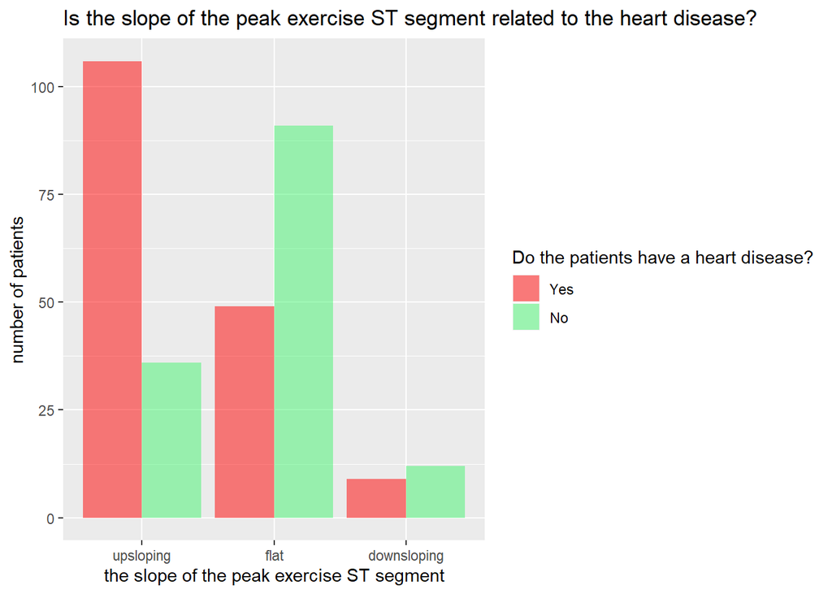

W tym przypadku zależność jest dość widoczna. W przypadku krzywej o charakterze “upsloping” u 3/4 pacjentów przydzielonych do tej grupy zdiagnozowana została choroba serca. Dla krzywej określonej jako “flat” 2/3 badanych nie zostało określonych mianem chorych, natomiast w przypadku krzywej “downsloping” próżno doszukiwać się jakiejkolwiek zależności (niewielkie różnice między słupkami, ale i same liczności grup też dość niewielkie).

# Zależność nr 4

Kolejna ciekawa zależność, której warto się przyjrzeć to relacja występująca pomiędzy wiekiem pacjentów, a ich maksymalnym tętnem. Zależność ta została zaprezentowana za pomocą boxplotów oraz z podziałem na pacjentów ze zdiagnozowaną chorobą serca oraz tymi, którzy nie mają takich problemów.

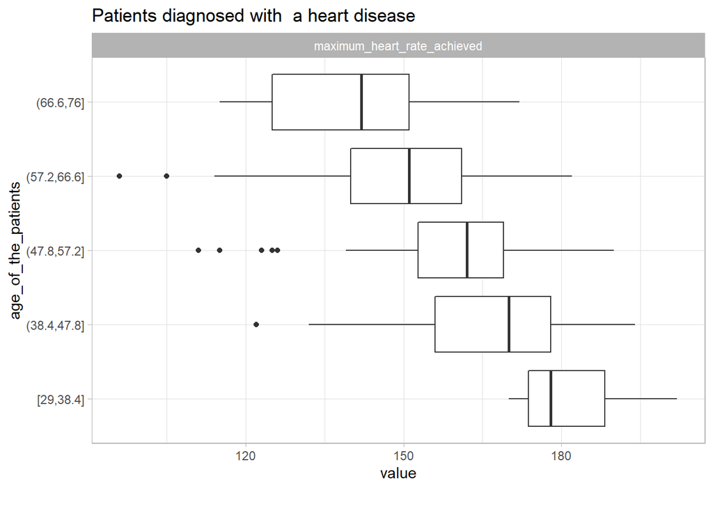

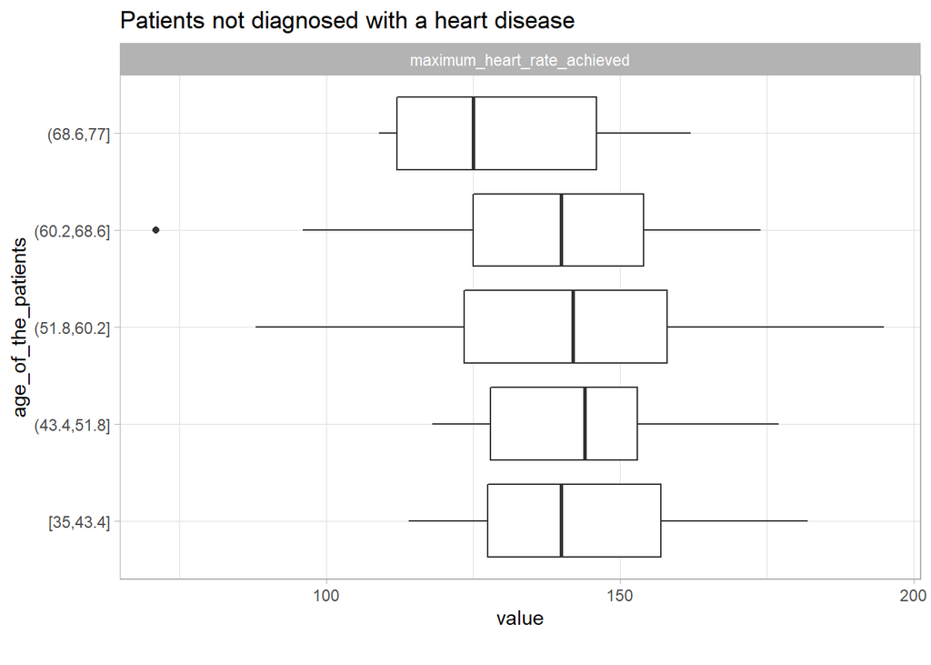

# Zależność nr 5

Do przedstawienia ostatniej zależności wykorzystamy heat mapę. Konkretnie chodzi o relację pomiędzy wspomnianym już nachyleniem krzywej otrzymywanej podczas badania EKG oraz rodzajem bólu odczuwanego przez pacjentów. Jest to również zależność, którą udało się zauważyć już podczas analizowania wykresu korelacji. Na poniższej heat mapie (podobnie jak w zależności nr 4) zastosujemy podział na osoby ze zdiagnozowaną chorobą serca i bez niej.

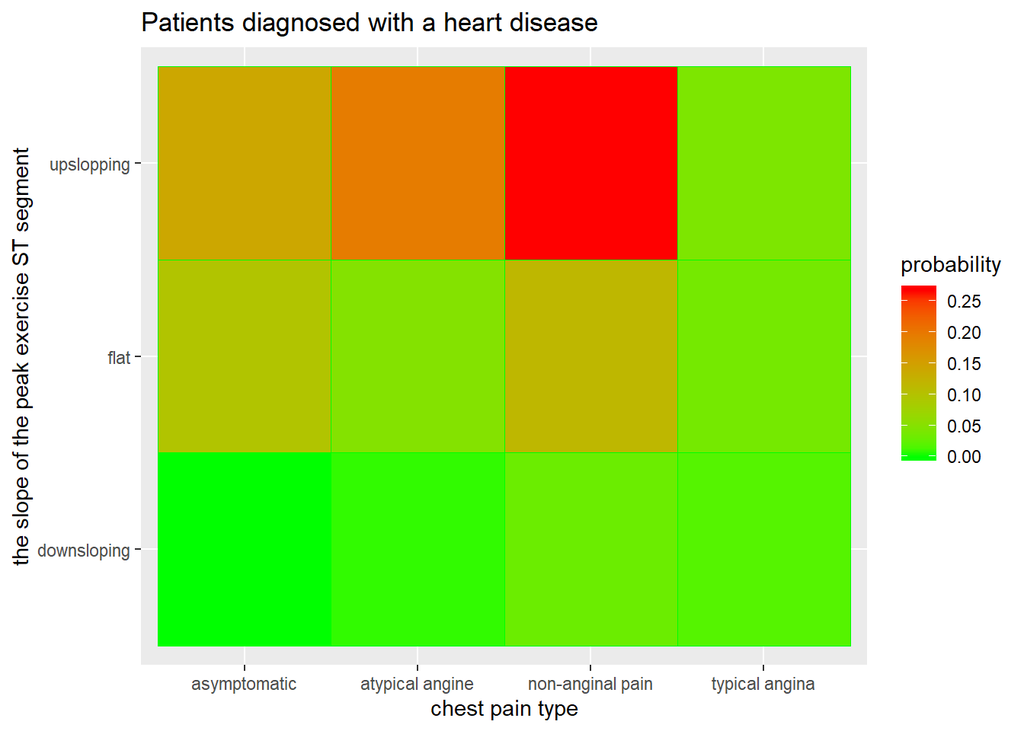

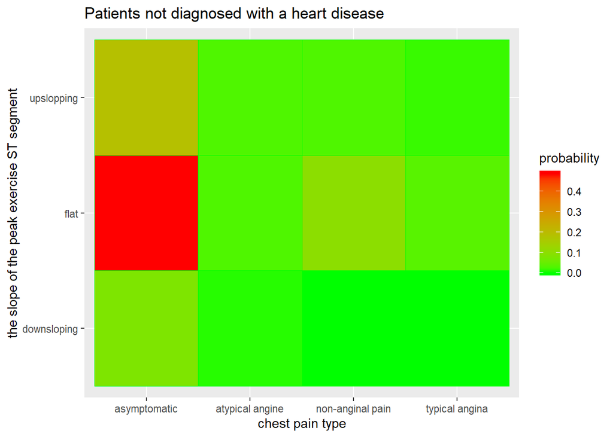

Widać, że badana zależność różni się u obu grup. Można zauważyć, że kombinacje krzywej “uplsloping” z bólem typu “atypical angine” lub “non-anginal pain” są typowe dla osób chorych, natomiast u pacjentów zdrowych ból określany jest najcześciej jako “asymptomatic”. W obu grupach ból typu “typical angina” pojawia się stosunkowo rzadko.

## Podsumowanie

Okazuje się, że z badanego zbioru można wyciągnąć przynajmniej kilka interesujących zależności. Większość z nich została odkryta już podczas analizy wykresu korelacji między kolumnami, a w następnych podrozdziałach jedynie przyjrzeliśmy się jej bliżej za pomocą czytelnych wykresów oraz krótkich opisów widocznych zależności.